# Assignment 3

Chadwick Reed

9/22/2020

# Introduction

This dataset is assembled with the intention of analyzing the extent to which internet access is a function of interstructural population density. It is well documented that internet access increases with regional population density: A downtown city center will undoubtedly have greater access than a rural farm town. This dataset attempts to test (or, rather, provide a means to test) whether the relationship between internet access and density holds true at the micro-scale; by assessing individual households across the state of California.

The following variables are included in the dataset:

**Continuous**  
NP: Number of persons per household  
GRPIP: Gross rent as proportion of household income  
OCPIP: Ownership costs as proportion of household income

**Categorical**  
BLD: Units per structure  
ACR: Lot size  
TEN: Tenure  
ACCESS: Internet access

This dataset includes a total of 378,817 observations.

```r
library(tidyverse)
library(tidycensus)
library(ggplot2)
library(prettyunits)
library(scales)

hh_data <- read_csv("hh_data.csv")
attach(hh_data)
hh_data_mod <- read_csv("hh_data.csv")
attach(hh_data_mod)
```

*Data cleaning:* In the interest of making the findings of this assignment more meaningful, I replaced all zeroes in GRPIP and OCPIP columns with ‘NA’, so that they will be excluded from statistical testing. I then created a third column, HPIP (housing as proportion of income) which combines these two variables and eliminates the broad distinction between tenure types. Notably, however, over twenty thousand observations in recorded N/A in both the GRPIP and OCPIP columns.

```r
#Replacing zeroes with NA
hh_data_mod$GRPIP[hh_data_mod$GRPIP == 0] <- NA
hh_data_mod$OCPIP[hh_data_mod$OCPIP == 0] <-NA
hh_data_mod$ACR[hh_data_mod$ACR == "b"] <- NA
hh_data_mod$BLD[hh_data_mod$BLD == "bb"] <- NA
hh_data_mod$TEN[hh_data_mod$TEN == "b"] <- NA
hh_data_mod$ACCESS[hh_data_mod$ACCESS == "b"] <- NA

#Creating new column for HPIP variable
hh_data_mod$HPIP <- ifelse(is.na(hh_data_mod$GRPIP), hh_data_mod$OCPIP, hh_data_mod$GRPIP)
```

# Relationships between two continuous variables

## Number of persons per household (NP), rent as proportion of income (GRPIP)

Weak/negligible, but statistically significant.

```r
correlation1 <- cor.test(hh_data_mod$NP, hh_data_mod$GRPIP)
correlation1
```

```
##
##  Pearson's product-moment correlation
##
## data:  hh_data_mod$NP and hh_data_mod$GRPIP
## t = -32.786, df = 132556, p-value < 2.2e-16
## alternative hypothesis: true correlation is not equal to 0
## 95 percent confidence interval:
##  -0.09502423 -0.08434430
## sample estimates:
##         cor
## -0.08968684
```

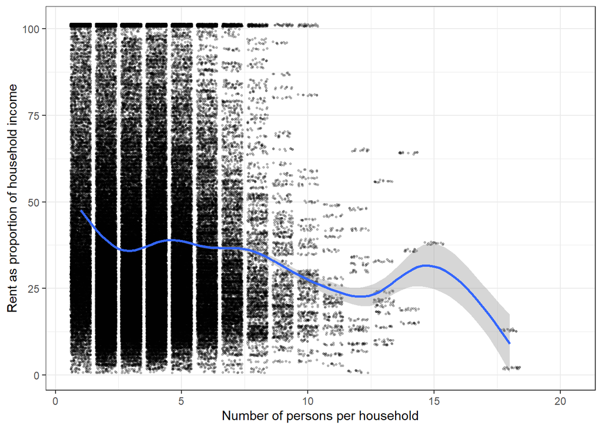

```r
ggplot(hh_data_mod, aes(x = NP, y = GRPIP)) +
    geom_point(size = 0.5, alpha = 0.25, position = "jitter") +
    geom_smooth() +
    theme_bw() +
    scale_x_continuous(name = "Number of persons per household") +
    scale_y_continuous(name = "Rent as proportion of household income")
```

## Number of persons per household (NP), ownership cost as proportion of income (OCPIP)

Weak/negligible, but statistically significant.

```r
correlation2 <- cor.test(hh_data_mod$NP, hh_data_mod$OCPIP)
correlation2
```

```
##
##  Pearson's product-moment correlation
##
## data:  hh_data_mod$NP and hh_data_mod$OCPIP
## t = -52.72, df = 222152, p-value < 2.2e-16
## alternative hypothesis: true correlation is not equal to 0
## 95 percent confidence interval:
##  -0.1152658 -0.1070519
## sample estimates:
##        cor
## -0.1111608
```

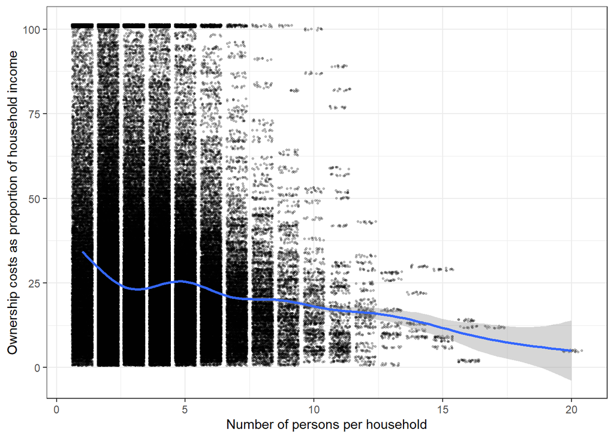

```r
ggplot(hh_data_mod, aes(x = NP, y = OCPIP)) +
    geom_point(size = 0.5, alpha = 0.25, position = "jitter") +
    geom_smooth() +
    theme_bw() +
    scale_x_continuous(name = "Number of persons per household") +
    scale_y_continuous(name = "Ownership costs as proportion of household income")
```

## Number of persons per household (NP), housing cost as proportion of income (HPIP)

Weak/negligible, but statistically significant.

```r
correlation3 <- cor.test(hh_data_mod$NP, hh_data_mod$HPIP)
correlation3
```

```
##
##  Pearson's product-moment correlation
##
## data:  hh_data_mod$NP and hh_data_mod$HPIP
## t = -57.838, df = 354710, p-value < 2.2e-16
## alternative hypothesis: true correlation is not equal to 0
## 95 percent confidence interval:
##  -0.09991720 -0.09339695
## sample estimates:
##         cor
## -0.09665811
```

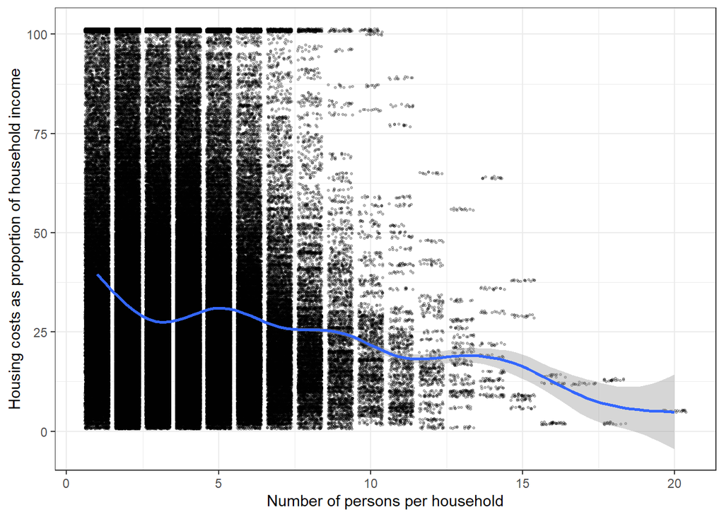

```r
ggplot(hh_data_mod, aes(x = NP, y = HPIP)) +
    geom_point(size = 0.5, alpha = 0.25, position = "jitter") +
    geom_smooth() +
    theme_bw() +
    scale_x_continuous(name = "Number of persons per household") +
    scale_y_continuous(name = "Housing costs as proportion of household income")
```

# Relationships between continuous and non-binary categorical variables

## Number of persons per household (NP), internet access (ACCESS)

A significant relationship exists. As the boxplot illustrates, CA respondents without internet access tend to have fewer people per household than respondents with internet access.

ANOVA test:

```r
anova <- aov(NP ~ ACCESS, data = hh_data_mod)

summary(anova)
```

```
##                 Df  Sum Sq Mean Sq F value Pr(>F)
## ACCESS           2   10603    5302    1477 <2e-16 ***
## Residuals   361901 1299378       4
## ---
## Signif. codes:  0 '***' 0.001 '**' 0.01 '*' 0.05 '.' 0.1 ' ' 1
## 16913 observations deleted due to missingness
```

Tukey’s HSD test:

```r
differences <- TukeyHSD(anova)

as_tibble(cbind(pair = row.names(differences$ACCESS),
                differences$ACCESS))
```

```
## # A tibble: 3 x 5
##   pair  diff              lwr               upr               `p adj`
##   <chr> <chr>             <chr>             <chr>             <chr>
## 1 2-1   -0.13708426126795 -0.1903410872691~ -0.0838274352667~ 4.83438966636385e~
## 2 3-1   -0.7439365264578~ -0.7761159707725~ -0.7117570821431~ 0
## 3 3-2   -0.6068522651899~ -0.6681215494668~ -0.5455829809129~ 0
```

Boxplot:

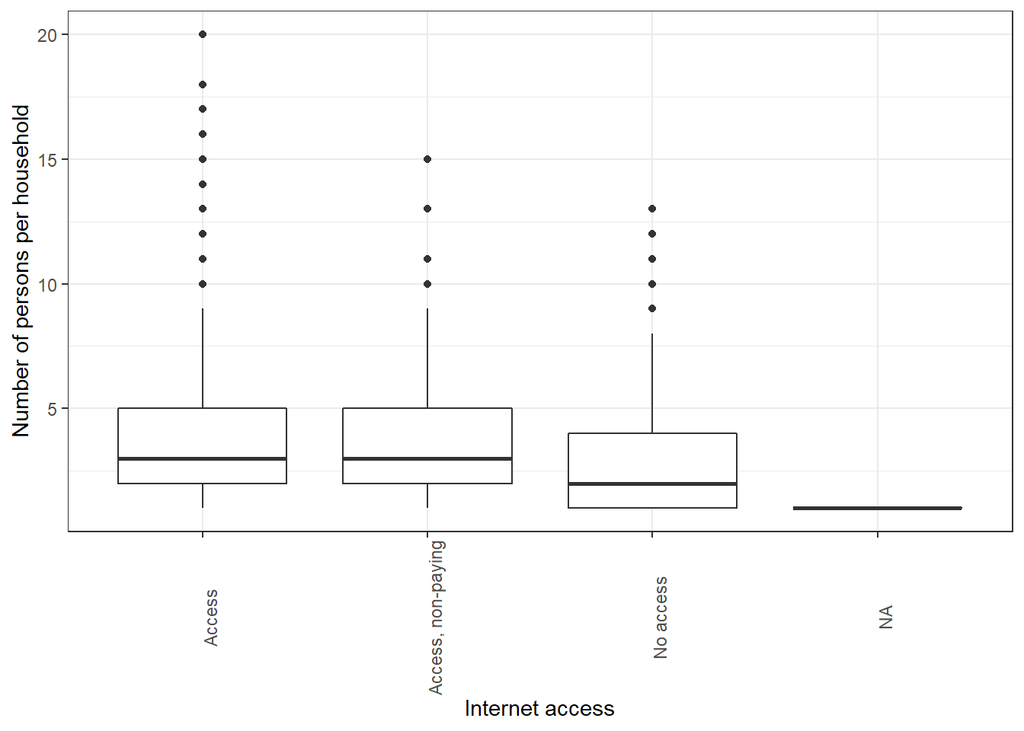

```r
ggplot(hh_data_mod, aes(x = ACCESS, y = NP)) +
  geom_boxplot() +
  theme_bw() +
  theme(axis.text.x = element_text(angle = 90)) +
  scale_x_discrete(name = "Internet access",
                   labels = c ("Access",
                                  "Access, non-paying",
                                  "No access")) +
  scale_y_continuous(name = "Number of persons per household")
```

## Number of persons per household (NP), lot size (ACR)

A significant relationship exists. As the boxplot illustrates, respondents with lot sizes of 10 acres or greater are less likely to have more than three people per household.

ANOVA test:

```r
anova <- aov(NP ~ ACR, data = hh_data_mod)

summary(anova)
```

```
##                 Df  Sum Sq Mean Sq F value Pr(>F)
## ACR              2    1456   728.1   195.4 <2e-16 ***
## Residuals   279487 1041195     3.7
## ---
## Signif. codes:  0 '***' 0.001 '**' 0.01 '*' 0.05 '.' 0.1 ' ' 1
## 99327 observations deleted due to missingness
```

Tukey’s HSD test:

```r
differences <- TukeyHSD(anova)

as_tibble(cbind(pair = row.names(differences$ACR),
                differences$ACR))
```

```
## # A tibble: 3 x 5
##   pair  diff              lwr               upr               `p adj`
##   <chr> <chr>             <chr>             <chr>             <chr>
## 1 2-1   -0.1783302608030~ -0.2111275665748~ -0.14553295503128 0
## 2 3-1   -0.4690030016772~ -0.5397008749825~ -0.3983051283719~ 0
## 3 3-2   -0.2906727408742~ -0.3675701502538~ -0.2137753314945~ 2.19824158875781e~
```

Boxplot:

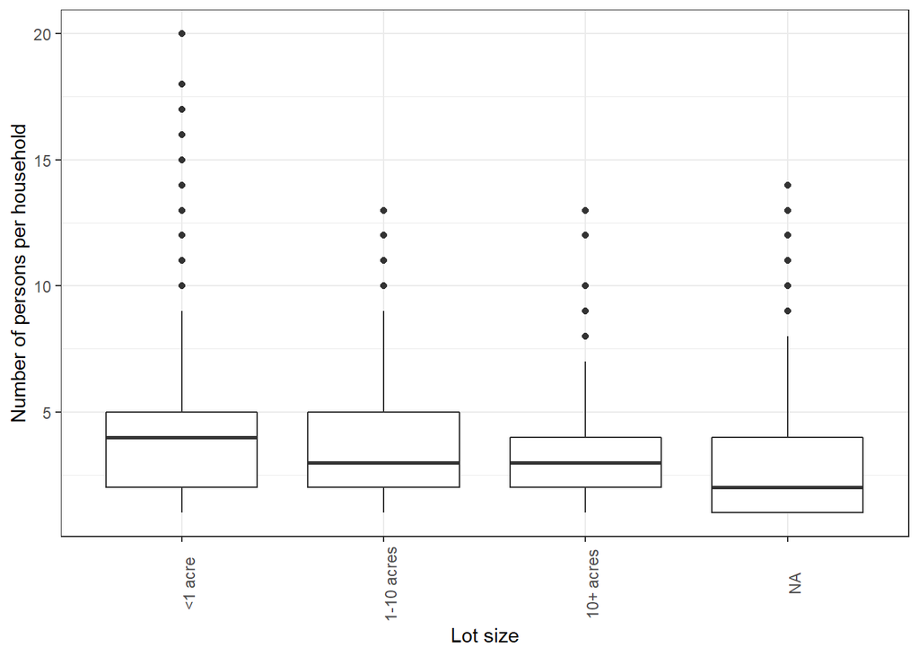

```r
ggplot(hh_data_mod, aes(x = ACR, y = NP)) +
  geom_boxplot() +
  theme_bw() +
  theme(axis.text.x = element_text(angle = 90)) +
  scale_x_discrete(name = "Lot size",
                   labels = c ("<1 acre",
                "1-10 acres",
                "10+ acres")) +
  scale_y_continuous(name = "Number of persons per household")
```

## Number of persons per household (NP), units per housing structure (BLD)

A significant relationship exists. As the boxplot illustrates, the median number of people per household in housing structures of 50 unites or more is significantly lower than for any other category of multi-unit housing structure.

ANOVA test:

```r
anova <- aov(NP ~ BLD, data = hh_data_mod)

summary(anova)
```

```
##                 Df  Sum Sq Mean Sq F value Pr(>F)
## BLD              9   40387    4487    1279 <2e-16 ***
## Residuals   361894 1269594       4
## ---
## Signif. codes:  0 '***' 0.001 '**' 0.01 '*' 0.05 '.' 0.1 ' ' 1
## 16913 observations deleted due to missingness
```

Tukey’s HSD test:

```r
differences <- TukeyHSD(anova)

as_tibble(cbind(pair = row.names(differences$BLD),
                differences$BLD))
```

```
## # A tibble: 45 x 5
##    pair  diff              lwr               upr              `p adj`
##    <chr> <chr>             <chr>             <chr>            <chr>
##  1 02-01 0.529033411263163 0.472113481880742 0.5859533406455~ 0
##  2 03-01 0.212846136853592 0.146417639487315 0.2792746342198~ 9.9031893796564e-~
##  3 04-01 0.171021262746744 0.08290538480541~ 0.2591371406880~ 3.6982180873224e-~
##  4 05-01 0.03328320240988~ -0.0393144990313~ 0.1058809038511~ 0.91112475828771
##  5 06-01 -0.0386302151194~ -0.1111429115767~ 0.0338824813378~ 0.804079322713
##  6 07-01 -0.2088905550589~ -0.2852478282940~ -0.132533281823~ 8.40438829641244e~
##  7 08-01 -0.2944895977516~ -0.3710456255866~ -0.217933569916~ 0
##  8 09-01 -0.6645499297367~ -0.7366493715567~ -0.592450487916~ 0
##  9 10-01 -0.5353431269538~ -0.87539694406257 -0.195289309845~ 2.79003454661808e~
## 10 03-02 -0.3161872744095~ -0.3544449600924~ -0.277929588726~ 0
## # ... with 35 more rows
```

Boxplot:

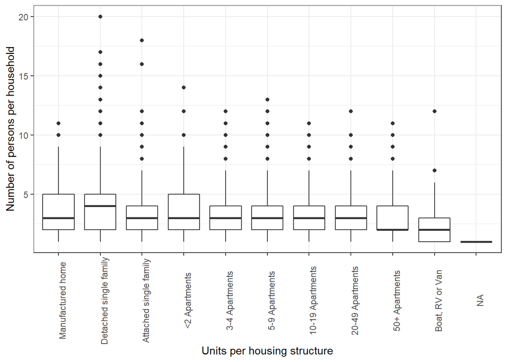

```r
ggplot(hh_data_mod, aes(x = BLD, y = NP)) +
  geom_boxplot() +
  theme_bw() +
  theme(axis.text.x = element_text(angle = 90)) +
  scale_x_discrete(name = "Units per housing structure",
                   labels = c ( "Manufactured home",
                            "Detached single family",
                            "Attached single family",
                            "<2 Apartments",
                            "3-4 Apartments",
                            "5-9 Apartments",
                            "10-19 Apartments",
                            "20-49 Apartments",
                            "50+ Apartments",
                            "Boat, RV or Van")) +
  scale_y_continuous(name = "Number of persons per household")
```

## Number of persons per household (NP), housing tenure (TEN)

ANOVA test:

```r
anova <- aov(NP ~ TEN, data = hh_data_mod)

summary(anova)
```

```
##                 Df  Sum Sq Mean Sq F value Pr(>F)
## TEN              3   18125    6042    1693 <2e-16 ***
## Residuals   361900 1291856       4
## ---
## Signif. codes:  0 '***' 0.001 '**' 0.01 '*' 0.05 '.' 0.1 ' ' 1
## 16913 observations deleted due to missingness
```

Tukey’s HSD:

```r
differences <- TukeyHSD(anova)

as_tibble(cbind(pair = row.names(differences$TEN),
                differences$TEN))
```

```
## # A tibble: 6 x 5
##   pair  diff                 lwr                upr              `p adj`
##   <chr> <chr>                <chr>              <chr>            <chr>
## 1 2-1   -0.619824570980462   -0.642738542584036 -0.596910599376~ 0
## 2 3-1   -0.159259229996241   -0.177193928873816 -0.141324531118~ 0
## 3 4-1   -0.62016571252383    -0.695099236108297 -0.545232188939~ 0
## 4 3-2   0.460565340984221    0.437024892186302  0.4841057897821~ 0
## 5 4-2   -0.0003411415433682~ -0.07681030044133~ 0.0761280173545~ 0.999999459323~
## 6 4-3   -0.460906482527589   -0.536033944828281 -0.385779020226~ 0
```

Boxplot:

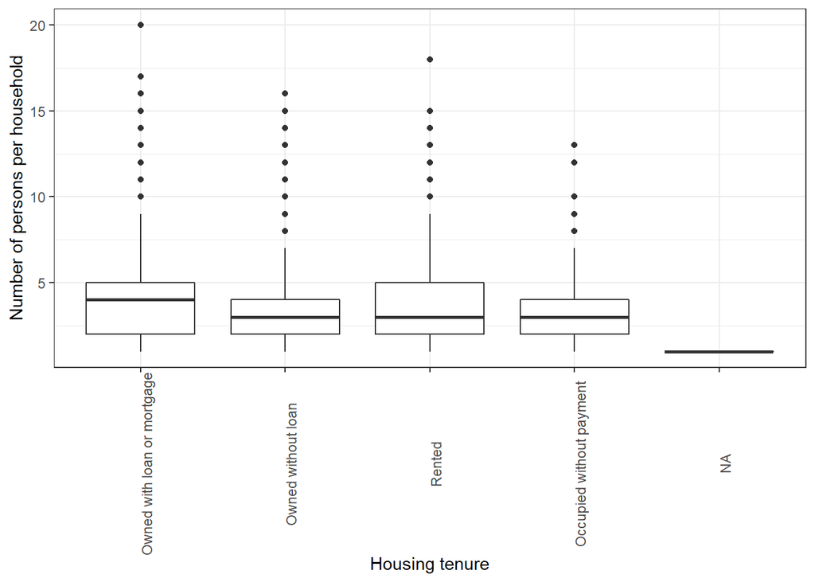

```r
ggplot(hh_data_mod, aes(x = TEN, y = NP)) +
  geom_boxplot() +
  theme_bw() +
  theme(axis.text.x = element_text(angle = 90)) +
  scale_x_discrete(name = "Housing tenure",
                   labels = c ( "Owned with loan or mortgage",
                                  "Owned without loan",
                                  "Rented", "Occupied without payment")) +
scale_y_continuous(name = "Number of persons per household")
```

## Housing cost as proportion of income (HPIP), internet access (ACCESS)

The relationship is significant. As the boxplot illustrates, housing costs tend to be a larger proportion of total household income in respondents without internet access.

ANOVA test:

```r
anova <- aov(HPIP ~ ACCESS, data = hh_data_mod)

summary(anova)
```

```
##                 Df    Sum Sq Mean Sq F value Pr(>F)
## ACCESS           2   2482888 1241444    2126 <2e-16 ***
## Residuals   354709 207091087     584
## ---
## Signif. codes:  0 '***' 0.001 '**' 0.01 '*' 0.05 '.' 0.1 ' ' 1
## 24105 observations deleted due to missingness
```

Tukey’s HSD test:

```r
differences <- TukeyHSD(anova)

as_tibble(cbind(pair = row.names(differences$ACCESS),
                differences$ACCESS))
```

```
## # A tibble: 3 x 5
##   pair  diff             lwr              upr              `p adj`
##   <chr> <chr>            <chr>            <chr>            <chr>
## 1 2-1   7.13439088443805 6.44083608119139 7.8279456876847  0
## 2 3-1   11.0375532737582 10.6159867891726 11.4591197583438 0
## 3 3-2   3.90316238932015 3.10364356876019 4.70268120988011 0
```

Boxplot:

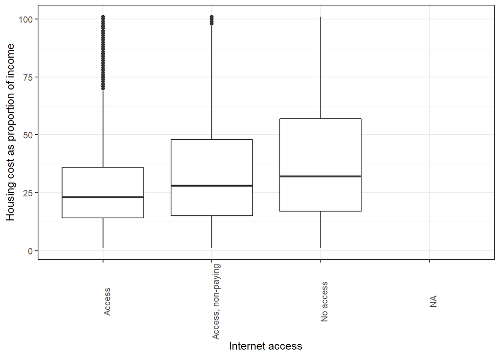

```r
ggplot(hh_data_mod, aes(x = ACCESS, y = HPIP)) +
  geom_boxplot() +
  theme_bw() +
  theme(axis.text.x = element_text(angle = 90)) +
  scale_x_discrete(name = "Internet access",
                   labels = c ("Access",
                                  "Access, non-paying",
                                  "No access")) +
  scale_y_continuous(name = "Housing cost as proportion of income")
```

## Housing cost as proportion of income (HPIP), lot size (ACR)

The relationship is significant. As the boxplot illustrates, housing cost as a proportion of income seems to decrease as lot size increases.

ANOVA test:

```r
anova <- aov(HPIP ~ ACR, data = hh_data_mod)

summary(anova)
```

```
##                 Df    Sum Sq Mean Sq F value   Pr(>F)
## ACR              2     35138   17569    33.2 3.85e-15 ***
## Residuals   274334 145191740     529
## ---
## Signif. codes:  0 '***' 0.001 '**' 0.01 '*' 0.05 '.' 0.1 ' ' 1
## 104480 observations deleted due to missingness
```

Tukey’s HSD test:

```r
differences <- TukeyHSD(anova)

as_tibble(cbind(pair = row.names(differences$ACR),
                differences$ACR))
```

```
## # A tibble: 3 x 5
##   pair  diff               lwr               upr              `p adj`
##   <chr> <chr>              <chr>             <chr>            <chr>
## 1 2-1   -1.26935010078929  -1.66513930172665 -0.873560899851~ 1.88182802673964e~
## 2 3-1   -1.28241482885588  -2.16840918659665 -0.396420471115~ 0.002002647370936~
## 3 3-2   -0.01306472806658~ -0.9714110153122~ 0.9452815591790~ 0.999437337869453
```

Boxplot:

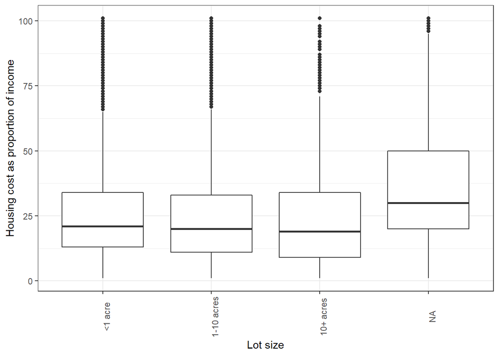

```r
ggplot(hh_data_mod, aes(x = ACR, y = HPIP)) +
  geom_boxplot() +
  theme_bw() +
  theme(axis.text.x = element_text(angle = 90)) +
  scale_x_discrete(name = "Lot size",
                   labels = c ("<1 acre",
                "1-10 acres",
                "10+ acres")) +
  scale_y_continuous(name = "Housing cost as proportion of income")
```

## Housing cost as proportion of income (HPIP), units per housing structure (BLD)

The relationship is significant. As the boxplot illustrates, the proportion of housing cost to household income tends to be highest for residents of buildings with 10 or more housing units.

ANOVA test:

```r
anova <- aov(HPIP ~ BLD, data = hh_data_mod)

summary(anova)
```

```
##                 Df    Sum Sq Mean Sq F value Pr(>F)
## BLD              9   7980126  886681    1560 <2e-16 ***
## Residuals   354702 201593850     568
## ---
## Signif. codes:  0 '***' 0.001 '**' 0.01 '*' 0.05 '.' 0.1 ' ' 1
## 24105 observations deleted due to missingness
```

Tukey’s HSD test:

```r
differences <- TukeyHSD(anova)

as_tibble(cbind(pair = row.names(differences$BLD),
                differences$BLD))
```

```
## # A tibble: 45 x 5
##    pair  diff              lwr                upr               `p adj`
##    <chr> <chr>             <chr>              <chr>             <chr>
##  1 02-01 0.566525362426898 -0.170901411897052 1.30395213675085  0.30742490531589
##  2 03-01 5.68471496559764  4.8254500660396    6.54397986515568  0
##  3 04-01 9.36004187171896  8.22017514317475   10.4999086002632  0
##  4 05-01 11.499118745981   10.5609977840674   12.4372397078947  0
##  5 06-01 11.4648529482716  10.5284088148093   12.4012970817339  0
##  6 07-01 12.6067405168678  11.62072007956     13.5927609541756  0
##  7 08-01 12.5230289433961  11.5320818767933   13.5139760099989  0
##  8 09-01 12.626176338159   11.6928108058497   13.5595418704682  0
##  9 10-01 -3.68111678633591 -8.22995306253752  0.867719489865701 0.2367937546793~
## 10 03-02 5.11818960317074  4.62577762745273   5.61060157888876  0
## # ... with 35 more rows
```

Boxplot:

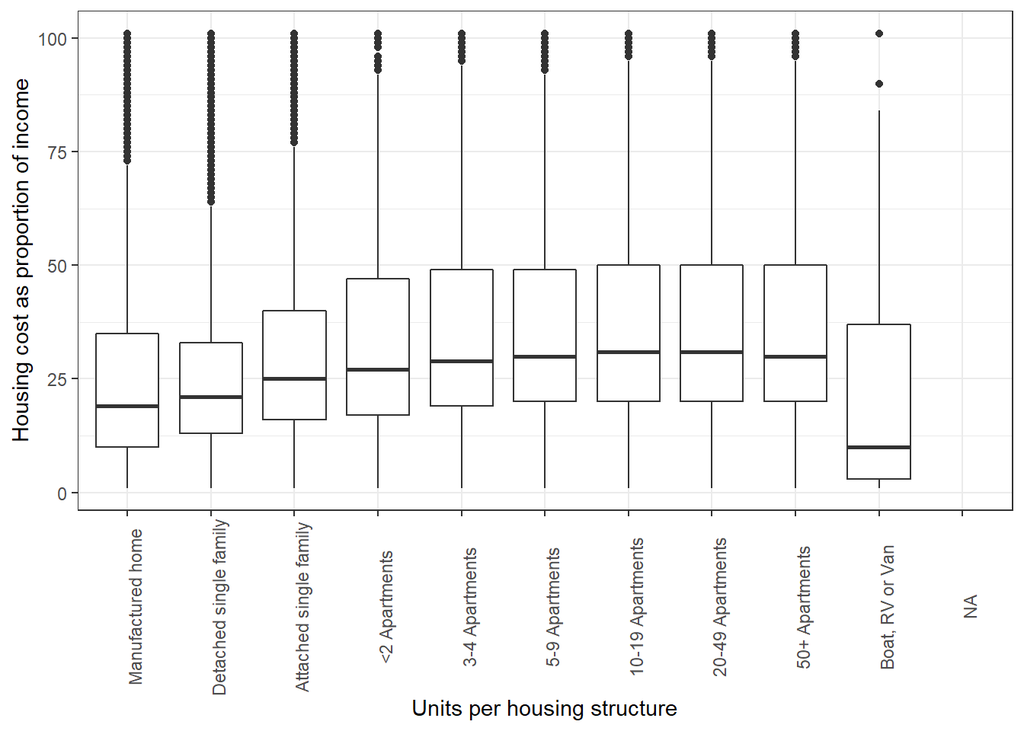

```r
ggplot(hh_data_mod, aes(x = BLD, y = HPIP)) +
  geom_boxplot() +
  theme_bw() +
  theme(axis.text.x = element_text(angle = 90)) +
  scale_x_discrete(name = "Units per housing structure",
                   labels = c ( "Manufactured home",
                            "Detached single family",
                            "Attached single family",
                            "<2 Apartments",
                            "3-4 Apartments",
                            "5-9 Apartments",
                            "10-19 Apartments",
                            "20-49 Apartments",
                            "50+ Apartments",
                            "Boat, RV or Van")) +
  scale_y_continuous(name = "Housing cost as proportion of income")
```

## Housing cost as proportion of income (HPIP), housing tenure (TEN)

The relationship is significant. As the boxplot illustrates, renters tend to have higher proportions of housing cost to income.

ANOVA test:

```r
anova <- aov(HPIP ~ TEN, data = hh_data_mod)

summary(anova)
```

```
##                 Df    Sum Sq  Mean Sq F value Pr(>F)
## TEN              2  24681303 12340652   23675 <2e-16 ***
## Residuals   354709 184892673      521
## ---
## Signif. codes:  0 '***' 0.001 '**' 0.01 '*' 0.05 '.' 0.1 ' ' 1
## 24105 observations deleted due to missingness
```

Tukey’s HSD:

```r
differences <- TukeyHSD(anova)

as_tibble(cbind(pair = row.names(differences$TEN),
                differences$TEN))
```

```
## # A tibble: 3 x 5
##   pair  diff              lwr               upr               `p adj`
##   <chr> <chr>             <chr>             <chr>             <chr>
## 1 2-1   -14.7460916123885 -14.9996818155556 -14.4925014092214 0
## 2 3-1   9.35214167130279  9.15356206601914  9.55072127658643  0
## 3 3-2   24.0982332836913  23.837324599842   24.3591419675405  0
```

Boxplot:

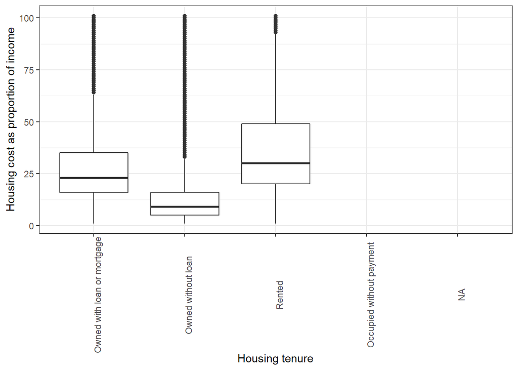

```r
ggplot(hh_data_mod, aes(x = TEN, y = HPIP)) +
  geom_boxplot() +
  theme_bw() +
  theme(axis.text.x = element_text(angle = 90)) +
  scale_x_discrete(name = "Housing tenure",
                   labels = c ( "Owned with loan or mortgage",
                                  "Owned without loan",
                                  "Rented", "Occupied without payment")) +
scale_y_continuous(name = "Housing cost as proportion of income")
```

# Relationships between two non-binary categorical variables

## Lot size (ACR), internet access (ACCESS)

### Households with internet access

The relationship is significant.

Chi-square test:

```r
chi_sq <- chisq.test(hh_data_mod$ACR, hh_data_mod$ACCESS ==
                       "1")

chi_sq
```

```
##
##  Pearson's Chi-squared test
##
## data:  hh_data_mod$ACR and hh_data_mod$ACCESS == "1"
## X-squared = 301.4, df = 2, p-value < 2.2e-16
```

```r
chi_sq$observed
```

```
##                hh_data_mod$ACCESS == "1"
## hh_data_mod$ACR  FALSE   TRUE
##               1  15673 239097
##               2   1441  19118
##               3    522   3639
```

```r
chi_sq$expected
```

```
##                hh_data_mod$ACCESS == "1"
## hh_data_mod$ACR      FALSE       TRUE
##               1 16076.1520 238693.848
##               2  1297.2862  19261.714
##               3   262.5618   3898.438
```

### Households with internet access for which they do not pay

The relationship is significant.

Chi-square test:

```r
chi_sq <- chisq.test(hh_data_mod$ACR, hh_data_mod$ACCESS ==
                       "2")

chi_sq
```

```
##
##  Pearson's Chi-squared test
##
## data:  hh_data_mod$ACR and hh_data_mod$ACCESS == "2"
## X-squared = 32.714, df = 2, p-value = 7.875e-08
```

```r
chi_sq$observed
```

```
##                hh_data_mod$ACCESS == "2"
## hh_data_mod$ACR  FALSE   TRUE
##               1 250665   4105
##               2  20231    328
##               3   4047    114
```

```r
chi_sq$expected
```

```
##                hh_data_mod$ACCESS == "2"
## hh_data_mod$ACR      FALSE       TRUE
##               1 250625.168 4144.83234
##               2  20224.527  334.47269
##               3   4093.305   67.69497
```

### Households without internet access

The relationship is significant.

Chi-square test:

```r
chi_sq <- chisq.test(hh_data_mod$ACR, hh_data_mod$ACCESS ==
                       "3")

chi_sq
```

```
##
##  Pearson's Chi-squared test
##
## data:  hh_data_mod$ACR and hh_data_mod$ACCESS == "3"
## X-squared = 280.75, df = 2, p-value < 2.2e-16
```

```r
chi_sq$observed
```

```
##                hh_data_mod$ACCESS == "3"
## hh_data_mod$ACR  FALSE   TRUE
##               1 243202  11568
##               2  19446   1113
##               3   3753    408
```

```r
chi_sq$expected
```

```
##                hh_data_mod$ACCESS == "3"
## hh_data_mod$ACR      FALSE       TRUE
##               1 242838.680 11931.3197
##               2  19596.186   962.8135
##               3   3966.133   194.8668
```

## Units per housing structure (BLD), internet access (ACCESS)

### Households with internet access

The relationship is significant.

Chi-square test:

```r
chi_sq <- chisq.test(hh_data_mod$BLD, hh_data_mod$ACCESS ==
                       "1")

chi_sq
```

```
##
##  Pearson's Chi-squared test
##
## data:  hh_data_mod$BLD and hh_data_mod$ACCESS == "1"
## X-squared = 4589.5, df = 9, p-value < 2.2e-16
```

```r
chi_sq$observed
```

```
##                hh_data_mod$ACCESS == "1"
## hh_data_mod$BLD  FALSE   TRUE
##              01   1834   9513
##              02  13997 227510
##              03   1805  24831
##              04    942   6577
##              05   1723  14414
##              06   1758  14471
##              07   1403  11431
##              08   1524  11169
##              09   2224  14466
##              10     86    226
```

```r
chi_sq$expected
```

```
##                hh_data_mod$ACCESS == "1"
## hh_data_mod$BLD       FALSE        TRUE
##              01   855.82837  10491.1716
##              02 18215.25894 223291.7411
##              03  2008.97546  24627.0245
##              04   567.10792   6951.8921
##              05  1217.10606  14919.8939
##              06  1224.04501  15004.9550
##              07   967.98285  11866.0172
##              08   957.34816  11735.6518
##              09  1258.81516  15431.1848
##              10    23.53207    288.4679
```

### Households with internet access for which they do not pay

The relationship is significant.

Chi-square test:

```r
chi_sq <- chisq.test(hh_data_mod$BLD, hh_data_mod$ACCESS ==
                       "2")

chi_sq
```

```
##
##  Pearson's Chi-squared test
##
## data:  hh_data_mod$BLD and hh_data_mod$ACCESS == "2"
## X-squared = 898.23, df = 9, p-value < 2.2e-16
```

```r
chi_sq$observed
```

```
##                hh_data_mod$ACCESS == "2"
## hh_data_mod$BLD  FALSE   TRUE
##              01  11042    305
##              02 237782   3725
##              03  26119    517
##              04   7269    250
##              05  15728    409
##              06  15797    432
##              07  12411    423
##              08  12299    394
##              09  16053    637
##              10    303      9
```

```r
chi_sq$expected
```

```
##                hh_data_mod$ACCESS == "2"
## hh_data_mod$BLD       FALSE        TRUE
##              01  11124.3580  222.642046
##              02 236768.3367 4738.663311
##              03  26113.3690  522.630963
##              04   7371.4680  147.531995
##              05  15820.3723  316.627716
##              06  15910.5671  318.432869
##              07  12582.1812  251.818808
##              08  12443.9478  249.052216
##              09  16362.5217  327.478254
##              10    305.8782    6.121822
```

### Households without internet access

The relationship is significant.

Chi-square test:

```r
chi_sq <- chisq.test(hh_data_mod$BLD, hh_data_mod$ACCESS ==
                       "3")

chi_sq
```

```
##
##  Pearson's Chi-squared test
##
## data:  hh_data_mod$BLD and hh_data_mod$ACCESS == "3"
## X-squared = 3846.2, df = 9, p-value < 2.2e-16
```

```r
chi_sq$observed
```

```
##                hh_data_mod$ACCESS == "3"
## hh_data_mod$BLD  FALSE   TRUE
##              01   9818   1529
##              02 231235  10272
##              03  25348   1288
##              04   6827    692
##              05  14823   1314
##              06  14903   1326
##              07  11854    980
##              08  11563   1130
##              09  15103   1587
##              10    235     77
```

```r
chi_sq$expected
```

```
##                hh_data_mod$ACCESS == "3"
## hh_data_mod$BLD       FALSE        TRUE
##              01  10713.8137   633.18633
##              02 228030.4044 13476.59563
##              03  25149.6555  1486.34450
##              04   7099.4241   419.57592
##              05  15236.5217   900.47835
##              06  15323.3879   905.61214
##              07  12117.8360   716.16404
##              08  11984.7041   708.29594
##              09  15758.6631   931.33690
##              10    294.5897    17.41025
```

### Households with internet access

The relationship is significant.

Chi-square test:

```r
chi_sq <- chisq.test(hh_data_mod$BLD, hh_data_mod$ACCESS ==
                       "1")

chi_sq
```

```
##
##  Pearson's Chi-squared test
##
## data:  hh_data_mod$BLD and hh_data_mod$ACCESS == "1"
## X-squared = 4589.5, df = 9, p-value < 2.2e-16
```

```r
chi_sq$observed
```

```
##                hh_data_mod$ACCESS == "1"
## hh_data_mod$BLD  FALSE   TRUE
##              01   1834   9513
##              02  13997 227510
##              03   1805  24831
##              04    942   6577
##              05   1723  14414
##              06   1758  14471
##              07   1403  11431
##              08   1524  11169
##              09   2224  14466
##              10     86    226
```

```r
chi_sq$expected
```

```
##                hh_data_mod$ACCESS == "1"
## hh_data_mod$BLD       FALSE        TRUE
##              01   855.82837  10491.1716
##              02 18215.25894 223291.7411
##              03  2008.97546  24627.0245
##              04   567.10792   6951.8921
##              05  1217.10606  14919.8939
##              06  1224.04501  15004.9550
##              07   967.98285  11866.0172
##              08   957.34816  11735.6518
##              09  1258.81516  15431.1848
##              10    23.53207    288.4679
```

### Households with internet access for which they do not pay

The relationship is significant.

Chi-square test:

```r
chi_sq <- chisq.test(hh_data_mod$BLD, hh_data_mod$ACCESS ==
                       "2")

chi_sq
```

```
##
##  Pearson's Chi-squared test
##
## data:  hh_data_mod$BLD and hh_data_mod$ACCESS == "2"
## X-squared = 898.23, df = 9, p-value < 2.2e-16
```

```r
chi_sq$observed
```

```
##                hh_data_mod$ACCESS == "2"
## hh_data_mod$BLD  FALSE   TRUE
##              01  11042    305
##              02 237782   3725
##              03  26119    517
##              04   7269    250
##              05  15728    409
##              06  15797    432
##              07  12411    423
##              08  12299    394
##              09  16053    637
##              10    303      9
```

```r
chi_sq$expected
```

```
##                hh_data_mod$ACCESS == "2"
## hh_data_mod$BLD       FALSE        TRUE
##              01  11124.3580  222.642046
##              02 236768.3367 4738.663311
##              03  26113.3690  522.630963
##              04   7371.4680  147.531995
##              05  15820.3723  316.627716
##              06  15910.5671  318.432869
##              07  12582.1812  251.818808
##              08  12443.9478  249.052216
##              09  16362.5217  327.478254
##              10    305.8782    6.121822
```

### Households without internet access

The relationship is significant.

Chi-square test:

```r
chi_sq <- chisq.test(hh_data_mod$BLD, hh_data_mod$ACCESS ==
                       "3")

chi_sq
```

```
##
##  Pearson's Chi-squared test
##
## data:  hh_data_mod$BLD and hh_data_mod$ACCESS == "3"
## X-squared = 3846.2, df = 9, p-value < 2.2e-16
```

```r
chi_sq$observed
```

```
##                hh_data_mod$ACCESS == "3"
## hh_data_mod$BLD  FALSE   TRUE
##              01   9818   1529
##              02 231235  10272
##              03  25348   1288
##              04   6827    692
##              05  14823   1314
##              06  14903   1326
##              07  11854    980
##              08  11563   1130
##              09  15103   1587
##              10    235     77
```

```r
chi_sq$expected
```

```
##                hh_data_mod$ACCESS == "3"
## hh_data_mod$BLD       FALSE        TRUE
##              01  10713.8137   633.18633
##              02 228030.4044 13476.59563
##              03  25149.6555  1486.34450
##              04   7099.4241   419.57592
##              05  15236.5217   900.47835
##              06  15323.3879   905.61214
##              07  12117.8360   716.16404
##              08  11984.7041   708.29594
##              09  15758.6631   931.33690
##              10    294.5897    17.41025
```

```r
write.csv("hh_data_mod.csv") -> hh_data_mod
```

```
## "","x"
## "1","hh_data_mod.csv"
```